# Recall performance for objects outside the rooms

# 1 Visual inspection of the data

```
## [1] "P17" "P54"
```

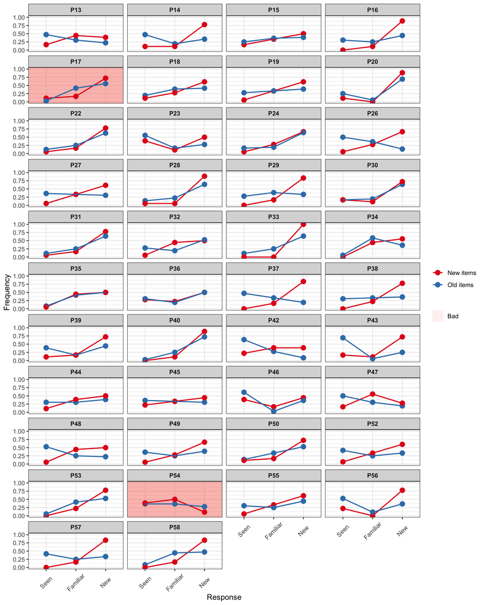

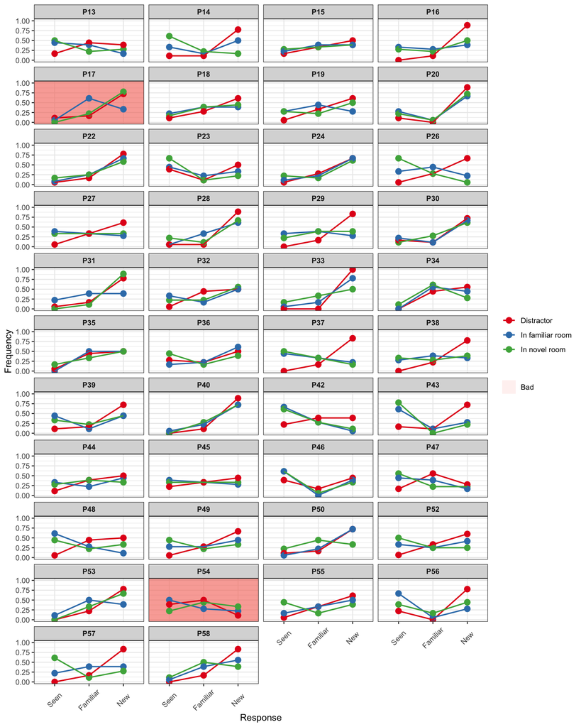

# 2 Novelty Benefits

## 2.1 Check the data

**Is there any corrected hit rate < 0?**

- There are 5 negative values out of a total of 80 values.

```
##    SubjectNo    Group MeanCurRt  MeanDur     SFHit       SHit    SrcHit
## 1:       P30    Novel  4.666667      NaN 0.3888889 0.11111111 0.1111111
## 2:       P31    Novel  6.000000      NaN 0.1111111 0.00000000 0.0000000
## 3:       P35 Familiar  3.000000      NaN 0.5000000 0.00000000 0.1666667
## 4:       P36 Familiar  5.000000      NaN 0.3888889 0.16666667 0.1111111
## 5:       P50 Familiar  2.000000 24.14499 0.2777778 0.05555556 0.1111111
##      SFFalse     SFalse   SrcFalse      SFAcc        SAcc      SrcAcc
## 1: 0.2777778 0.16666667 0.09259259  0.1111111 -0.05555556  0.01851852
## 2: 0.2222222 0.05555556 0.07407407 -0.1111111 -0.05555556 -0.07407407
## 3: 0.5000000 0.05555556 0.16666667  0.0000000 -0.05555556  0.00000000
## 4: 0.5000000 0.27777778 0.16666667 -0.1111111 -0.11111111 -0.05555556
## 5: 0.2777778 0.11111111 0.09259259  0.0000000 -0.05555556  0.01851852
```

## 2.2 Compare mean accuracy between *novel* and *familiar* rooms

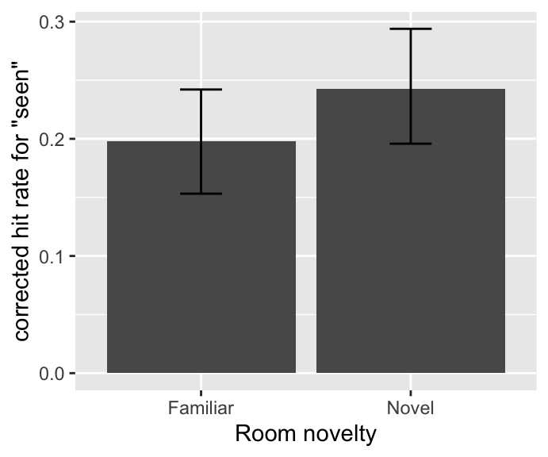

Figure1. Mean accuracy for item memory respectively for Familiar and Novel rooms.

```
##       Group      Mean        SD  N
## 1:    Novel 0.2427778 0.1720323 40
## 2: Familiar 0.1976389 0.1499334 40
```

```
##
##  Paired t-test
##
## data:  SAcc by Group
## t = -1.9572, df = 39, p-value = 0.05751
## alternative hypothesis: true difference in means is not equal to 0
## 95 percent confidence interval:
##  -0.091788142  0.001510364
## sample estimates:
## mean of the differences
##             -0.04513889
```

## 2.3 Any difference between *Early* and *Later* object groups?

### 2.3.1 Check the data

- **Is there any corrected hit rate < 0?**
  - There are 14 negative values out of a total of 160 values.

```
##     SubjectNo    Group ObjOrdGrp MeanCurRt  MeanDur     SFHit      SHit
##  1:       P22    Novel     Early  6.000000      NaN 0.1666667 0.0000000
##  2:       P22 Familiar     Later  2.500000      NaN 0.1666667 0.0000000
##  3:       P23 Familiar     Later  5.000000      NaN 0.4444444 0.2222222
##  4:       P28 Familiar     Later  1.333333      NaN 0.2222222 0.0000000
##  5:       P30    Novel     Early  4.666667      NaN 0.2222222 0.1111111
##  6:       P30    Novel     Later  4.666667      NaN 0.5555556 0.1111111
##  7:       P31    Novel     Later  6.000000      NaN 0.0000000 0.0000000
##  8:       P31    Novel     Early  6.000000      NaN 0.2222222 0.0000000
##  9:       P35 Familiar     Early  3.000000      NaN 0.5555556 0.0000000
## 10:       P35 Familiar     Later  3.000000      NaN 0.4444444 0.0000000
## 11:       P36 Familiar     Early  5.000000      NaN 0.3333333 0.2222222
## 12:       P36 Familiar     Later  5.000000      NaN 0.4444444 0.1111111
## 13:       P45    Novel     Later  6.000000 32.32439 0.4444444 0.1111111
## 14:       P50 Familiar     Later  2.000000 24.14499 0.2222222 0.0000000
```

[output cut: 30 more lines]

### 2.3.2 Visualise the data

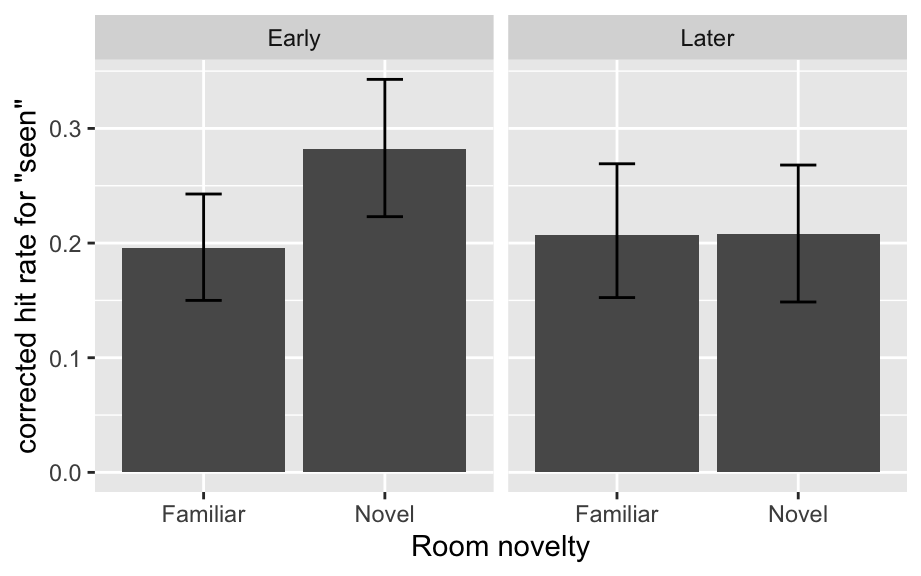

### 2.3.3 Repeated-measures ANOVA

```
##       Group ObjOrdGrp      Mean        SD  N
## 1:    Novel     Early 0.2816667 0.2008300 40
## 2: Familiar     Later 0.2066667 0.1921011 40
## 3:    Novel     Later 0.2080556 0.1984905 40
## 4: Familiar     Early 0.1955556 0.1532140 40
```

```
## $ANOVA
##            Effect DFn DFd        F          p p<.05         ges
## 2           Group   1  39 3.765197 0.05958397       0.013817965
## 3       ObjOrdGrp   1  39 1.566498 0.21817156       0.007098022
## 4 Group:ObjOrdGrp   1  39 5.197858 0.02816444     * 0.012965755
```

### 2.3.4 *Post hoc*

#### 2.3.4.1 Early

```
##
##  Paired t-test
##
## data:  SAcc by Group
## t = -2.8547, df = 39, p-value = 0.006865
## alternative hypothesis: true difference in means is not equal to 0
## 95 percent confidence interval:
##  -0.14712468 -0.02509754
## sample estimates:
## mean of the differences
##             -0.08611111
```

#### 2.3.4.2 Later

```
##
##  Paired t-test
##
## data:  SAcc by Group
## t = -0.049188, df = 39, p-value = 0.961
## alternative hypothesis: true difference in means is not equal to 0
## 95 percent confidence interval:
##  -0.05850173  0.05572395
## sample estimates:
## mean of the differences
##            -0.001388889
```

# 3 Curiosity Enhancement

## 3.1 Check the data

### 3.1.1 Is there any corrected hit rate < 0?

#### 3.1.1.1 For the data per room

- There are 35 negative values out of a total of 236 values.

```
##     SubjectNo     Context    Group CurRating RoomOrder Duration     SFHit
##  1:       P15         Gym Familiar         4    Second       NA 0.5000000
##  2:       P15 StorageRoom    Novel         5     First       NA 0.3333333
##  3:       P18     Bedroom Familiar         2    Second       NA 0.6666667
##  4:       P18   Classroom Familiar         5    Second       NA 0.3333333
##  5:       P18  LivingRoom    Novel         7     First       NA 0.3333333
##  6:       P20   Classroom Familiar         4     First       NA 0.0000000
##  7:       P20     Library    Novel         2     First       NA 0.0000000
##  8:       P20 StorageRoom    Novel         6    Second       NA 0.1666667
##  9:       P22   Classroom    Novel         7    Second       NA 0.1666667
## 10:       P22     Library Familiar         2     First       NA 0.3333333
## 11:       P23     Library Familiar         4    Second       NA 0.5000000
## 12:       P23  LivingRoom Familiar         4    Second       NA 0.5000000
## 13:       P24     Bedroom    Novel         6    Second       NA 0.1666667
## 14:       P24     Library Familiar         2     First       NA 0.1666667
```

[output cut: 96 more lines]

#### 3.1.1.2 For the data per curiosity group

- There are 6 negative value for curiosity group (1 ~ 3 and 5 ~ 7) out of a total of 76 values.

```
##    SubjectNo CurGrp  MeanDur      SFHit       SHit     SrcHit   SFFalse
## 1:       P18   High      NaN 0.44444444 0.05555556 0.05555556 0.3888889
## 2:       P24    Low      NaN 0.08333333 0.00000000 0.08333333 0.3333333
## 3:       P31   High      NaN 0.11111111 0.00000000 0.00000000 0.2222222
## 4:       P35    Low      NaN 0.58333333 0.00000000 0.25000000 0.5000000
## 5:       P36    Low      NaN 0.33333333 0.00000000 0.16666667 0.5000000
## 6:       P50    Low 24.14499 0.27777778 0.05555556 0.11111111 0.2777778
##        SFalse   SrcFalse       SFAcc        SAcc       SrcAcc
## 1: 0.11111111 0.12962963  0.05555556 -0.05555556 -0.074074074
## 2: 0.05555556 0.07407407 -0.25000000 -0.05555556  0.009259259
## 3: 0.05555556 0.07407407 -0.11111111 -0.05555556 -0.074074074
## 4: 0.05555556 0.16666667  0.08333333 -0.05555556  0.083333333
## 5: 0.27777778 0.16666667 -0.16666667 -0.27777778  0.000000000
## 6: 0.11111111 0.09259259  0.00000000 -0.05555556  0.018518519
```

#### 3.1.1.3 For the data per curiosity group (median)

- There are 6 negative value for curiosity group (median) out of a total of 79 values.

```
##    SubjectNo CurGrpMedian  MeanDur     SFHit       SHit     SrcHit
## 1:       P18         High      NaN 0.4444444 0.05555556 0.05555556
## 2:       P30          Low      NaN 0.2500000 0.08333333 0.08333333
## 3:       P31         High      NaN 0.1111111 0.00000000 0.00000000
## 4:       P35          Low      NaN 0.5000000 0.00000000 0.16666667
## 5:       P36          Low      NaN 0.3888889 0.22222222 0.22222222
## 6:       P50          Low 24.14499 0.2777778 0.05555556 0.11111111
##      SFFalse     SFalse   SrcFalse       SFAcc        SAcc       SrcAcc
## 1: 0.3888889 0.11111111 0.12962963  0.05555556 -0.05555556 -0.074074074
## 2: 0.2777778 0.16666667 0.09259259 -0.02777778 -0.08333333 -0.009259259
## 3: 0.2222222 0.05555556 0.07407407 -0.11111111 -0.05555556 -0.074074074
## 4: 0.5000000 0.05555556 0.16666667  0.00000000 -0.05555556  0.000000000
## 5: 0.5000000 0.27777778 0.16666667 -0.11111111 -0.05555556  0.055555556
## 6: 0.2777778 0.11111111 0.09259259  0.00000000 -0.05555556  0.018518519
```

## 3.2 Mean accuracy of item memory as a function of curiosity rating

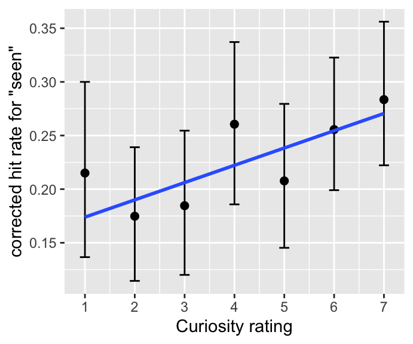

## 3.3 Testing the relationship between mean accuracy of item memory and curiosity rating

Build models with item memory accuracy as $y$ and examine effects of curiosity rating by including it into the model and then comparing the model fits.

- `baseline.rating` is the model with only an intercept, showing no change in item memory as a function of curiosity rating.
- `rating.intercept` is the model with $\small CuriosityRating$ included, showing the effects of curiosity rating.
- `rating.slope` is the model allowing the slope (i.e., relationship between item memory and curiosity rating) varying across participants.

```
##                  Model df       AIC        BIC   logLik   Test  L.Ratio
## baseline.rating      1  3 -112.4064 -102.01487 59.20318
## rating.intercept     2  4 -115.8169 -101.96155 61.90844 1 vs 2 5.410516
## rating.slope         3  6 -117.0497  -96.26669 64.52484 2 vs 3 5.232807
##                  p-value
## baseline.rating
## rating.intercept  0.0200
## rating.slope      0.0731
```

```
## Linear mixed-effects model fit by maximum likelihood
##  Data: outside.hit.rate.per.room
##         AIC       BIC   logLik
##   -117.0497 -96.26669 64.52484
##
## Random effects:
##  Formula: ~1 + CurRating | SubjectNo
##  Structure: General positive-definite, Log-Cholesky parametrization
##             StdDev     Corr
## (Intercept) 0.14855048 (Intr)
## CurRating   0.02897839 -0.649
## Residual    0.15613739
##
## Fixed effects: SAcc ~ CurRating
##                  Value  Std.Error  DF  t-value p-value
## (Intercept) 0.16395570 0.03657540 195 4.482677  0.0000
## CurRating   0.01374472 0.00740357 195 1.856498  0.0649
##  Correlation:
##           (Intr)
## CurRating -0.815
##
## Standardized Within-Group Residuals:
##        Min         Q1        Med         Q3        Max
## -1.9476639 -0.6220212 -0.1395588  0.5360562  2.7936277
##
## Number of Observations: 236
## Number of Groups: 40
```

## 3.4 Check the curiosity groups

### 3.4.1 Separate the groups according to the rating

- *High*: curiosity rating > 4
- *Low*: curiosity rating < 4
- For curiosity rating = 4, discarded

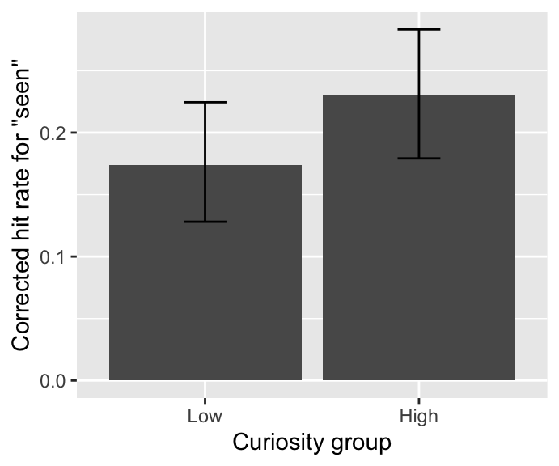

```
##    CurGrp      Mean        SD  N
## 1:   High 0.2307639 0.1726816 40
## 2:    Low 0.1740741 0.1488048 36
```

```
## Linear mixed-effects model fit by maximum likelihood
##  Data: outside.hit.rate.curiosity.group
##         AIC       BIC   logLik
##   -57.02269 -43.03829 34.51135
##
## Random effects:
##  Formula: ~1 + CurGrp | SubjectNo
##  Structure: General positive-definite, Log-Cholesky parametrization
##             StdDev     Corr
## (Intercept) 0.13246705 (Intr)
## CurGrpHigh  0.15589286 -0.408
## Residual    0.06368553
##
## Fixed effects: SAcc ~ CurGrp
##                  Value  Std.Error DF  t-value p-value
## (Intercept) 0.17443032 0.02466030 39 7.073324  0.0000
## CurGrpHigh  0.05633357 0.02976085 35 1.892875  0.0667
##  Correlation:
##            (Intr)
## CurGrpHigh -0.509
##
## Standardized Within-Group Residuals:
##         Min          Q1         Med          Q3         Max
## -0.80097391 -0.33256971 -0.05357216  0.25930693  1.13454089
##
## Number of Observations: 76
## Number of Groups: 40
```

#### 3.4.1.1 Curiosity groups and temporal order of the objects

##### 3.4.1.1.1 Check the data

- **Is there any corrected hit rate < 0?**
  - There are 28 negative values out of a total of 200 values.

```
##     SubjectNo CurGrp ObjOrdGrp     SFHit      SHit    SrcHit   SFFalse
##  1:       P14    Low     Later 0.3333333 0.0000000 0.3333333 0.2222222
##  2:       P15   <NA>     Early 0.1666667 0.0000000 0.1666667 0.5000000
##  3:       P15    Low     Later 0.6666667 0.0000000 0.6666667 0.5000000
##  4:       P18   High     Later 0.3333333 0.0000000 0.0000000 0.3888889
##  5:       P20   <NA>     Later 0.0000000 0.0000000 0.0000000 0.1111111
##  6:       P20   <NA>     Early 0.0000000 0.0000000 0.0000000 0.1111111
##  7:       P22   High     Early 0.1666667 0.0000000 0.0000000 0.2222222
##  8:       P22    Low     Later 0.1666667 0.0000000 0.0000000 0.2222222
##  9:       P23   <NA>     Later 0.1666667 0.0000000 0.1666667 0.5000000
## 10:       P24    Low     Early 0.0000000 0.0000000 0.0000000 0.3333333
## 11:       P24    Low     Later 0.1666667 0.0000000 0.1666667 0.3333333
## 12:       P27    Low     Later 0.5000000 0.0000000 0.3333333 0.3888889
## 13:       P28    Low     Later 0.2222222 0.0000000 0.1111111 0.1111111
## 14:       P30   <NA>     Later 0.3333333 0.0000000 0.1666667 0.2777778
```

[output cut: 45 more lines]

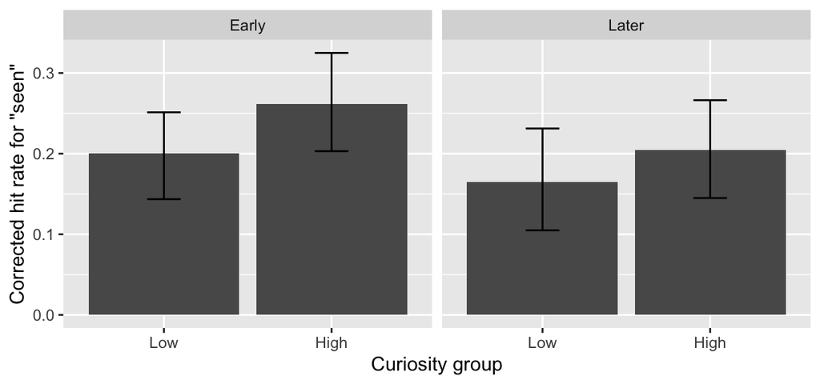

```
##    CurGrp ObjOrdGrp      Mean        SD  N
## 1:   High     Early 0.2615278 0.1985719 40
## 2:    Low     Later 0.1648148 0.2007482 36
## 3:   High     Later 0.2048611 0.1976283 40
## 4:    Low     Early 0.2003086 0.1729602 36
```

```
##           Model df       AIC       BIC   logLik   Test  L.Ratio p-value
## baseline      1  8 -68.64217 -44.45112 42.32108
## ord.model     2  9 -70.59205 -43.37713 44.29603 1 vs 2 3.949886  0.0469
## cur.model     3 10 -71.57741 -41.33861 45.78871 2 vs 3 2.985359  0.0840
## int.model     4 11 -69.76934 -36.50665 45.88467 3 vs 4 0.191926  0.6613
```

```
## Linear mixed-effects model fit by maximum likelihood
##  Data: outside.hit.rate.item.order.curiosity
##         AIC       BIC   logLik
##   -69.76934 -36.50665 45.88467
##
## Random effects:
##  Formula: ~1 + CurGrp + ObjOrdGrp | SubjectNo
##  Structure: General positive-definite, Log-Cholesky parametrization
##                StdDev     Corr
## (Intercept)    0.09769586 (Intr) CrGrpH
## CurGrpHigh     0.09498281 -0.294
## ObjOrdGrpLater 0.06482057 -0.108  0.698
## Residual       0.14575448
##
## Fixed effects: SAcc ~ ObjOrdGrp + CurGrp + ObjOrdGrp:CurGrp
##                                 Value  Std.Error  DF   t-value p-value
## (Intercept)                0.20114161 0.02956186 109  6.804093  0.0000
## ObjOrdGrpLater            -0.03587113 0.03644372 109 -0.984289  0.3272
## CurGrpHigh                 0.06038617 0.03749593 109  1.610473  0.1102
## ObjOrdGrpLater:CurGrpHigh -0.02079553 0.04807484 109 -0.432566  0.6662
##  Correlation:
##                           (Intr) ObjOGL CrGrpH
## ObjOrdGrpLater            -0.584
## CurGrpHigh                -0.631  0.528
## ObjOrdGrpLater:CurGrpHigh  0.430 -0.696 -0.642
##
## Standardized Within-Group Residuals:
##        Min         Q1        Med         Q3        Max
## -1.6356533 -0.6813181 -0.1723696  0.5637259  2.6844448
##
## Number of Observations: 152
## Number of Groups: 40
```

### 3.4.2 Separate the groups according to the median rating of each participant

- *High*: curiosity rating > median of the participant
- *Low*: curiosity rating < median of the participant

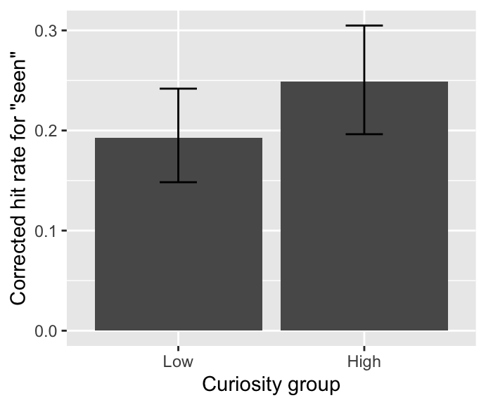

```
## Linear mixed-effects model fit by maximum likelihood
##  Data: outside.hit.rate.curiosity.group.median
##         AIC      BIC   logLik
##   -66.97538 -52.7587 39.48769
##
## Random effects:
##  Formula: ~1 + CurGrpMedian | SubjectNo
##  Structure: General positive-definite, Log-Cholesky parametrization
##                  StdDev     Corr
## (Intercept)      0.13748160 (Intr)
## CurGrpMedianHigh 0.12905976 -0.283
## Residual         0.06018526
##
## Fixed effects: SAcc ~ CurGrpMedian
##                       Value  Std.Error DF  t-value p-value
## (Intercept)      0.19277778 0.02403564 39 8.020497  0.0000
## CurGrpMedianHigh 0.05317795 0.02503166 38 2.124428  0.0402
##  Correlation:
##                  (Intr)
## CurGrpMedianHigh -0.368
##
## Standardized Within-Group Residuals:
##         Min          Q1         Med          Q3         Max
## -0.78663179 -0.36168756 -0.04679393  0.32140660  1.11481715
##
## Number of Observations: 79
## Number of Groups: 40
```

#### 3.4.2.1 Curiosity groups and temporal order of the objects

##### 3.4.2.1.1 Check the data

- **Is there any corrected hit rate < 0?**
  - There are 14 negative values out of a total of 164 values.

```
##     SubjectNo CurGrpMedian ObjOrdGrp     SFHit      SHit    SrcHit
##  1:       P18         High     Later 0.3333333 0.0000000 0.0000000
##  2:       P22         High     Early 0.1666667 0.0000000 0.0000000
##  3:       P22          Low     Later 0.1666667 0.0000000 0.0000000
##  4:       P23          Low     Later 0.2222222 0.1111111 0.1111111
##  5:       P28          Low     Later 0.2222222 0.0000000 0.1111111
##  6:       P30          Low     Later 0.3333333 0.0000000 0.1666667
##  7:       P31         High     Later 0.0000000 0.0000000 0.0000000
##  8:       P31         High     Early 0.2222222 0.0000000 0.0000000
##  9:       P35          Low     Early 0.5555556 0.0000000 0.1111111
## 10:       P35          Low     Later 0.4444444 0.0000000 0.2222222
## 11:       P36          Low     Later 0.4444444 0.1111111 0.2222222
## 12:       P39         High     Later 0.3333333 0.0000000 0.1666667
## 13:       P45         High     Later 0.4444444 0.1111111 0.1111111
## 14:       P50          Low     Later 0.2222222 0.0000000 0.1111111
##       SFFalse     SFalse   SrcFalse       SFAcc        SAcc      SrcAcc
##  1: 0.3888889 0.11111111 0.12962963 -0.05555556 -0.11111111 -0.12962963
##  2: 0.2222222 0.05555556 0.09259259 -0.05555556 -0.05555556 -0.09259259
##  3: 0.2222222 0.05555556 0.09259259 -0.05555556 -0.05555556 -0.09259259
##  4: 0.5000000 0.38888889 0.16666667 -0.27777778 -0.27777778 -0.05555556
##  5: 0.1111111 0.05555556 0.07407407  0.11111111 -0.05555556  0.03703704
##  6: 0.2777778 0.16666667 0.09259259  0.05555556 -0.16666667  0.07407407
##  7: 0.2222222 0.05555556 0.07407407 -0.22222222 -0.05555556 -0.07407407
##  8: 0.2222222 0.05555556 0.07407407  0.00000000 -0.05555556 -0.07407407
##  9: 0.5000000 0.05555556 0.16666667  0.05555556 -0.05555556 -0.05555556
## 10: 0.5000000 0.05555556 0.16666667 -0.05555556 -0.05555556  0.05555556
## 11: 0.5000000 0.27777778 0.16666667 -0.05555556 -0.16666667  0.05555556
## 12: 0.2777778 0.11111111 0.09259259  0.05555556 -0.11111111  0.07407407
## 13: 0.5555556 0.22222222 0.12962963 -0.11111111 -0.11111111 -0.01851852
## 14: 0.2777778 0.11111111 0.09259259 -0.05555556 -0.11111111  0.01851852
```

##### 3.4.2.1.2 Visualise the data

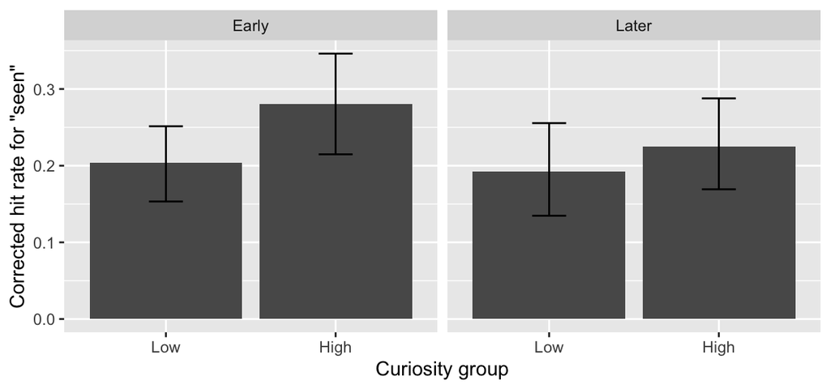

##### 3.4.2.1.3 Run the analysis

```
##    CurGrpMedian ObjOrdGrp      Mean        SD  N
## 1:         High     Early 0.2803419 0.2064500 39
## 2:          Low     Later 0.1927778 0.1985632 40
## 3:         High     Later 0.2247863 0.1942056 39
## 4:          Low     Early 0.2038889 0.1565000 40
```

```
##           Model df       AIC       BIC   logLik   Test  L.Ratio p-value
## baseline      1  8 -89.15473 -64.65397 52.57736
## ord.model     2  9 -89.53121 -61.96786 53.76561 1 vs 2 2.376485  0.1232
## cur.model     3 10 -91.85423 -61.22828 55.92711 2 vs 3 4.323011  0.0376
## int.model     4 11 -90.95734 -57.26879 56.47867 3 vs 4 1.103115  0.2936
```

```
## Linear mixed-effects model fit by maximum likelihood
##  Data: outside.hit.rate.item.order.curiosity.median
##         AIC       BIC   logLik
##   -91.85423 -61.22828 55.92711
##
## Random effects:
##  Formula: ~1 + CurGrpMedian + ObjOrdGrp | SubjectNo
##  Structure: General positive-definite, Log-Cholesky parametrization
##                  StdDev     Corr
## (Intercept)      0.11015102 (Intr) CrGrMH
## CurGrpMedianHigh 0.06585109  0.006
## ObjOrdGrpLater   0.07222896 -0.147  0.615
## Residual         0.13457814
##
## Fixed effects: SAcc ~ ObjOrdGrp + CurGrpMedian
##                        Value  Std.Error  DF   t-value p-value
## (Intercept)       0.21490744 0.02563201 116  8.384337  0.0000
## ObjOrdGrpLater   -0.03314821 0.02451634 116 -1.352086  0.1790
## CurGrpMedianHigh  0.05104585 0.02418231 116  2.110876  0.0369
##  Correlation:
##                  (Intr) ObjOGL
## ObjOrdGrpLater   -0.420
## CurGrpMedianHigh -0.371  0.127
##
## Standardized Within-Group Residuals:
##         Min          Q1         Med          Q3         Max
## -1.87717110 -0.60051601 -0.06724342  0.62075353  2.36127792
##
## Number of Observations: 158
## Number of Groups: 40
```

###### 3.4.2.1.3.1 *Post hoc*

```
##
##   Simultaneous Tests for General Linear Hypotheses
##
## Fit: lme.formula(fixed = SAcc ~ ObjOrdGrp + CurGrpMedian + ObjOrdGrp:CurGrpMedian,
##     data = outside.hit.rate.item.order.curiosity.median, random = ~1 +
##         CurGrpMedian + ObjOrdGrp | SubjectNo, method = "ML",
##     na.action = na.exclude, control = list(msMaxIter = 500, opt = "optim",
##         msVerbose = FALSE))
##
## Linear Hypotheses:
##                          Estimate Std. Error z value Pr(>|z|)
## Early: High vs. Low == 0  0.07336    0.03191   2.299   0.0215 *
## Late:  High vs. Low == 0  0.02864    0.03197   0.896   0.3704
## ---
## Signif. codes:  0 '***' 0.001 '**' 0.01 '*' 0.05 '.' 0.1 ' ' 1
## (Adjusted p values reported -- none method)
```

# 4 **Novelty** or **Curiosity**?

There are 35 negative values in a total of 236 values.

```
##     SubjectNo     Context    Group CurRating RoomOrder Duration     SFHit
##  1:       P15         Gym Familiar         4    Second       NA 0.5000000
##  2:       P15 StorageRoom    Novel         5     First       NA 0.3333333
##  3:       P18     Bedroom Familiar         2    Second       NA 0.6666667
##  4:       P18   Classroom Familiar         5    Second       NA 0.3333333
##  5:       P18  LivingRoom    Novel         7     First       NA 0.3333333
##  6:       P20   Classroom Familiar         4     First       NA 0.0000000
##  7:       P20     Library    Novel         2     First       NA 0.0000000
##  8:       P20 StorageRoom    Novel         6    Second       NA 0.1666667
##  9:       P22   Classroom    Novel         7    Second       NA 0.1666667
## 10:       P22     Library Familiar         2     First       NA 0.3333333
## 11:       P23     Library Familiar         4    Second       NA 0.5000000
## 12:       P23  LivingRoom Familiar         4    Second       NA 0.5000000
## 13:       P24     Bedroom    Novel         6    Second       NA 0.1666667
## 14:       P24     Library Familiar         2     First       NA 0.1666667
```

[output cut: 96 more lines]

## 4.1 For Curiosity group splitted by score (*Low*: 1 ~ 3; *High*: 5 ~ 7)

### 4.1.1 Curiosity first, novelty next

```
##               Model df       AIC       BIC   logLik   Test  L.Ratio
## base.model        1  8 -91.35010 -64.68835 53.67505
## cur.scr.model     2  9 -92.64200 -62.64753 55.32100 1 vs 2 3.291897
## nov.scr.model     3 10 -90.79823 -57.47104 55.39911 2 vs 3 0.156231
##               p-value
## base.model
## cur.scr.model  0.0696
## nov.scr.model  0.6927
```

```
## Linear mixed-effects model fit by maximum likelihood
##  Data: outside.hit.rate.per.room[!is.na(CurGrp)]
##       AIC       BIC logLik
##   -92.642 -62.64753 55.321
##
## Random effects:
##  Formula: ~1 + CurGrp + Group | SubjectNo
##  Structure: General positive-definite, Log-Cholesky parametrization
##             StdDev      Corr
## (Intercept) 0.138792193 (Intr) CrGrpL
## CurGrpLow   0.109152090 -0.658
## GroupNovel  0.003015334  0.009 -0.003
## Residual    0.156930488
##
## Fixed effects: SAcc ~ CurGrp
##                  Value  Std.Error  DF   t-value p-value
## (Intercept)  0.2437452 0.02633443 166  9.255764  0.0000
## CurGrpLow   -0.0561362 0.02945163 166 -1.906048  0.0584
##  Correlation:
##           (Intr)
## CurGrpLow -0.598
##
## Standardized Within-Group Residuals:
##        Min         Q1        Med         Q3        Max
## -2.0356108 -0.6251782 -0.1766418  0.4994973  2.5691106
##
## Number of Observations: 207
## Number of Groups: 40
```

### 4.1.2 Novelty first, curiosity next

```
##               Model df       AIC       BIC   logLik   Test   L.Ratio
## base.model        1  8 -91.35010 -64.68835 53.67505
## nov.scr.model     2  9 -91.89944 -61.90497 54.94972 1 vs 2 2.5493422
## cur.scr.model     3 10 -90.79823 -57.47104 55.39911 2 vs 3 0.8987858
##               p-value
## base.model
## nov.scr.model  0.1103
## cur.scr.model  0.3431
```

```
## Linear mixed-effects model fit by maximum likelihood
##  Data: outside.hit.rate.per.room[!is.na(CurGrp)]
##         AIC       BIC   logLik
##   -91.89944 -61.90497 54.94972
##
## Random effects:
##  Formula: ~1 + CurGrp + Group | SubjectNo
##  Structure: General positive-definite, Log-Cholesky parametrization
##             StdDev      Corr
## (Intercept) 0.138327166 (Intr) CrGrpL
## CurGrpLow   0.110950888 -0.643
## GroupNovel  0.009626985  0.073 -0.002
## Residual    0.156805213
##
## Fixed effects: SAcc ~ Group
##                  Value  Std.Error  DF  t-value p-value
## (Intercept) 0.19504801 0.02400426 166 8.125559  0.0000
## GroupNovel  0.04462097 0.02639925 166 1.690236  0.0929
##  Correlation:
##            (Intr)
## GroupNovel -0.467
##
## Standardized Within-Group Residuals:
##        Min         Q1        Med         Q3        Max
## -2.0774046 -0.6000275 -0.1951575  0.4791262  2.5887750
##
## Number of Observations: 207
## Number of Groups: 40
```

## 4.2 For Curiosity group splitted by individual medians

### 4.2.1 Curiosity first, novelty next

```
##              Model df       AIC       BIC   logLik   Test  L.Ratio p-value
## base.model       1  8 -95.55778 -68.15818 55.77889
## cur.md.model     2  9 -97.22429 -66.39974 57.61214 1 vs 2 3.666502  0.0555
## nov.md.model     3 10 -95.35700 -61.10750 57.67850 2 vs 3 0.132717  0.7156
```

```
## Linear mixed-effects model fit by maximum likelihood
##  Data: outside.hit.rate.per.room[!is.na(CurGrpMedian)]
##         AIC       BIC   logLik
##   -97.22429 -66.39974 57.61214
##
## Random effects:
##  Formula: ~1 + CurGrpMedian + Group | SubjectNo
##  Structure: General positive-definite, Log-Cholesky parametrization
##                 StdDev      Corr
## (Intercept)     0.137725153 (Intr) CrGrML
## CurGrpMedianLow 0.064560023 -0.700
## GroupNovel      0.006378346 -0.069  0.070
## Residual        0.164471223
##
## Fixed effects: SAcc ~ CurGrpMedian
##                       Value  Std.Error  DF   t-value p-value
## (Intercept)      0.25310095 0.02697557 186  9.382600  0.0000
## CurGrpMedianLow -0.04751255 0.02434016 186 -1.952023  0.0524
##  Correlation:
##                 (Intr)
## CurGrpMedianLow -0.616
##
## Standardized Within-Group Residuals:
##        Min         Q1        Med         Q3        Max
## -2.0867117 -0.6968285 -0.1123524  0.6058880  2.5000761
##
## Number of Observations: 227
## Number of Groups: 40
```

### 4.2.2 Novelty first, curiosity next

```
##              Model df       AIC       BIC   logLik   Test  L.Ratio p-value
## base.model       1  8 -95.55778 -68.15818 55.77889
## nov.md.model     2  9 -96.79488 -65.97033 57.39744 1 vs 2 3.237096  0.0720
## cur.md.model     3 10 -95.35700 -61.10750 57.67850 2 vs 3 0.562123  0.4534
```

```
## Linear mixed-effects model fit by maximum likelihood
##  Data: outside.hit.rate.per.room[!is.na(CurGrpMedian)]
##         AIC       BIC   logLik
##   -96.79488 -65.97033 57.39744
##
## Random effects:
##  Formula: ~1 + CurGrpMedian + Group | SubjectNo
##  Structure: General positive-definite, Log-Cholesky parametrization
##                 StdDev      Corr
## (Intercept)     0.135145540 (Intr) CrGrML
## CurGrpMedianLow 0.064369232 -0.626
## GroupNovel      0.002625827  0.000  0.018
## Residual        0.164338478
##
## Fixed effects: SAcc ~ Group
##                  Value  Std.Error  DF  t-value p-value
## (Intercept) 0.20539239 0.02327205 186 8.825710  0.0000
## GroupNovel  0.04426389 0.02385493 186 1.855545  0.0651
##  Correlation:
##            (Intr)
## GroupNovel -0.388
##
## Standardized Within-Group Residuals:
##        Min         Q1        Med         Q3        Max
## -2.1015509 -0.6434292 -0.0890030  0.5668606  2.5247333
##
## Number of Observations: 227
## Number of Groups: 40
```